# Analysis of Step Activity for Peer Assessment #1 Of Coursera Reproducible Research Course

```r
## Calculate Median of New Dataframe

nonamediansteps<-median(newsumupdate$Steps)
cat("Median number of steps per day across all days without NAs:", nonamediansteps, "\n")
```

```
## Median number of steps per day across all days without NAs:
```

```r
## Calculate Mean Steps Per Interval With NAs Excluded By Aggregating Steps and Interval

newmeanstepint<-aggregate(Steps~Interval, nonaactivity, mean)

colnames(newmeanstepint)[colnames(newmeanstepint) == "Interval"] <- 'Interval'
colnames(newmeanstepint)[colnames(newmeanstepint) == "Steps"] <- 'NewMeanSteps'

newactdata<-merge(nonaactivity, newmeanstepint, by="Interval")
```

12. Calculate mean steps per interval over weekdays vs. weekends, bind together into one file, round step numbers and plot.

```r
weekdayact<-newactdata[newactdata$DayOrEnd=="Weekday",]
weekdayactmean<-aggregate(Steps~Interval, weekdayact, mean)
weekendact<-newactdata[newactdata$DayOrEnd=="Weekend",]
weekendactmean<-aggregate(Steps~Interval, weekendact, mean)
weekendactmean$DayOrEnd<-"Weekend"
weekdayactmean$DayOrEnd<-"Weekday"

dayend<-rbind(weekendactmean, weekdayactmean)
dayend$Steps<-round(dayend$Steps, 3)
```

13. Create panel plots to show activity differences between weekend days and weekday days

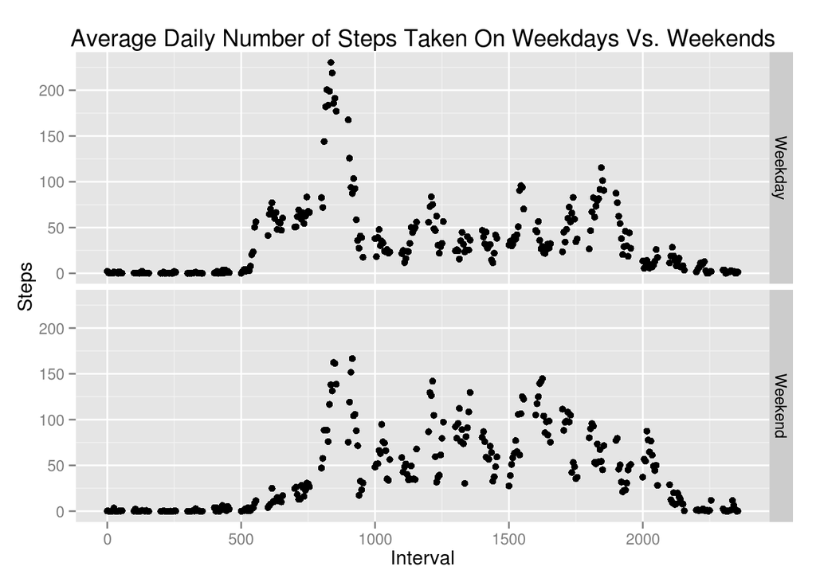

[output not shown]

With weekend activity, the highest peak happened at roughly 850 but not at nearly the height of the weekday’s and perhaps one-fourth higher than the peaks that followed. Walking activites went later (past 2000) on the weekends than on the weekdays.